# Homework 7

Nicole R. Gorman

2024-03-03

## Creating Fake Data Sets To Explore Hypotheses

- Think about an ongoing study in your lab (or a paper you have read in a different class), and decide on a pattern that you might expect in your experiment if a specific hypothesis were true.
- To start simply, assume that the data in each of your treatment groups follow a normal distribution. Specify the sample sizes, means, and variances for each group that would be reasonable if your hypothesis were true. You may need to consult some previous literature and/or an expert in the field to come up with these numbers.  
  **Study background**  
  *Cells must move materials in order to maintain metabolic processes. Some intracellular movement of materials is accomplished with endosomal trafficking. In plants, defects in trafficking pathways can lead to mutant phenotypes such as short roots. A protein complex known as the retriever has been well characterized in humans, but has yet to be completely explored in plants. Building on previous work in the lab, I am currently working on continuing to the characterize the retreiver in Arabidopsis thaliana. One approach to this question is identifying candidate Arabidopsis mutants with short root phenotypes. Identification of mutant phenotypes provides a foundation for exploring the proteins that may be components of the retreiver in this model species. The data set used in this analysis was generated from the observation of root length phenotypes of putative components of retriever.*  
  *The typical sample size for analysis of root length phenotypes is n = 10 plants/genotype/treatment with 3 independent biological replicates. For this particular dataset, the data need to be reformatted, so only the first replicate is included with this analysis to help simplify. In the future, data will be formatted differently to simplify downstream analyses.*
- Open libraries

```r
library(ggplot2) # for graphics
library(MASS) # for maximum likelihood estimation
library(dplyr)
```

- Read in and plot the data

```r
# Read in the data
z <- read.csv("/Users/nicolegorman/Documents/UVM_Research/UVM Rotation Project/ACC Trials/CBIO_ACCTrials.csv",header=TRUE,sep=",")

# Use regular expressions to subset genotype and then add this column to the dataset
# SEARCH: (\w+_)(\w+),(.*) REPLACE: \2

vecg <- read.csv("/Users/nicolegorman/Documents/UVM_Research/UVM Rotation Project/ACC Trials/CBIO_ACCTrials_Genotypes.csv",header=TRUE,sep=",")

# subset the genotype column
genotype <- vecg$Genotype

# add vecg as a column to the dataset
z$Genotype <- genotype

# get the structure and summary metrics of the new dataset
str(z)
```

```
## 'data.frame':    1200 obs. of  3 variables:
##  $ Plant.ID: chr  "1_1_0nM_WT" "1_1_0nM_WT" "1_1_0nM_WT" "1_1_0nM_WT" ...
##  $ Length  : num  3.57 8.17 11.35 14.27 16.14 ...
##  $ Genotype: chr  "WT" "WT" "WT" "WT" ...
```

```r
summary(z)
```

```
##    Plant.ID             Length         Genotype
##  Length:1200        Min.   : 0.610   Length:1200
##  Class :character   1st Qu.: 7.342   Class :character
##  Mode  :character   Median :10.520   Mode  :character
##                     Mean   :10.829
##                     3rd Qu.:13.943
##                     Max.   :23.310
##                     NA's   :196
```

```r
# take a peek to make sure that the genotype column is all there
head (z)
```

```
##     Plant.ID Length Genotype
## 1 1_1_0nM_WT   3.57       WT
## 2 1_1_0nM_WT   8.17       WT
## 3 1_1_0nM_WT  11.35       WT
## 4 1_1_0nM_WT  14.27       WT
## 5 1_1_0nM_WT  16.14       WT
## 6 1_2_0nM_WT   6.22       WT
```

```r
tail (z)
```

```
##                Plant.ID Length  Genotype
## 1195  1_9_1uM_ccdc93RFP 13.515 ccdc93RFP
## 1196 1_10_1uM_ccdc93RFP     NA ccdc93RFP
## 1197 1_10_1uM_ccdc93RFP     NA ccdc93RFP
## 1198 1_10_1uM_ccdc93RFP     NA ccdc93RFP
## 1199 1_10_1uM_ccdc93RFP     NA ccdc93RFP
## 1200 1_10_1uM_ccdc93RFP     NA ccdc93RFP
```

```r
# Remove NAs here
z<-na.omit(z)
# get the structure of z wuithout the NAs
str(z)
```

```
## 'data.frame':    1004 obs. of  3 variables:
##  $ Plant.ID: chr  "1_1_0nM_WT" "1_1_0nM_WT" "1_1_0nM_WT" "1_1_0nM_WT" ...
##  $ Length  : num  3.57 8.17 11.35 14.27 16.14 ...
##  $ Genotype: chr  "WT" "WT" "WT" "WT" ...
##  - attr(*, "na.action")= 'omit' Named int [1:196] 246 247 248 249 250 296 297 298 299 300 ...
##   ..- attr(*, "names")= chr [1:196] "246" "247" "248" "249" ...
```

```r
# Use myVar for my response variable (length) so I can run the code with any response variable by
# changing the variable name to myVar
z$myVar <- z$Length

# define variables for easier downstream analysis
ID <- seq_len(nrow(z)) # creates a sequence from 1:n (if n > 0!)
varA <- z$Plant.ID
varB <- z$Genotype
myVar <- z$Length

head(ID)
```

```
## [1] 1 2 3 4 5 6
```

```r
head (varA)
```

```
## [1] "1_1_0nM_WT" "1_1_0nM_WT" "1_1_0nM_WT" "1_1_0nM_WT" "1_1_0nM_WT"
## [6] "1_2_0nM_WT"
```

```r
head(varB)
```

```
## [1] "WT" "WT" "WT" "WT" "WT" "WT"
```

```r
head (myVar)
```

```
## [1]  3.57  8.17 11.35 14.27 16.14  6.22
```

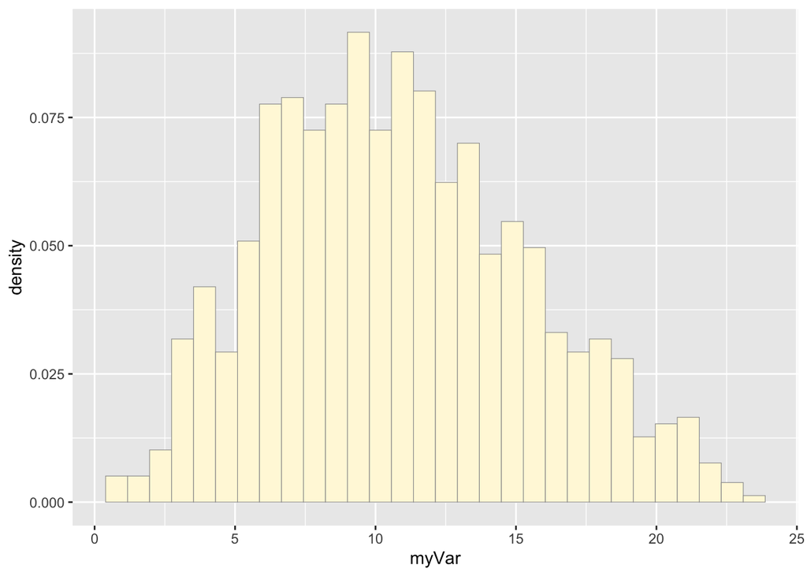

```r
# Plot histogram of data
p1 <- ggplot(data=z, aes(x=myVar, y=..density..)) +
  geom_histogram(color="grey60",fill="cornsilk",linewidth=0.2)
print(p1)
```

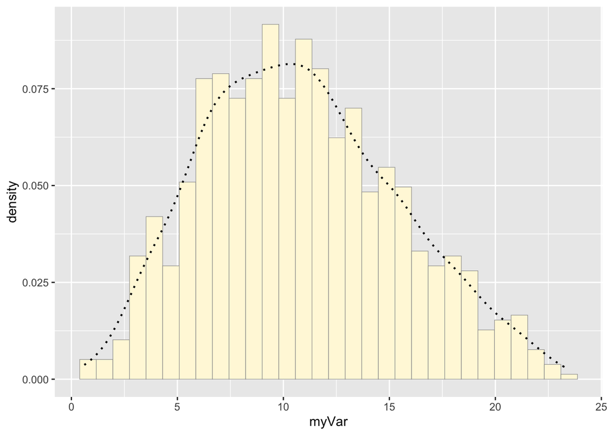

```r
# Add empirical density curve to smooth out the profile of the distribution
p1 <-  p1 +  geom_density(linetype="dotted",size=0.75)
print(p1)
```

```r
# Get maximum likelihood parameters for the normal distribution
normPars <- fitdistr(z$myVar,"normal")
print(normPars)
```

```
##       mean          sd
##   10.8289333    4.5714441
##  ( 0.1442735) ( 0.1020168)
```

```r
str(normPars)
```

```
## List of 5
##  $ estimate: Named num [1:2] 10.83 4.57
##   ..- attr(*, "names")= chr [1:2] "mean" "sd"
##  $ sd      : Named num [1:2] 0.144 0.102
##   ..- attr(*, "names")= chr [1:2] "mean" "sd"
##  $ vcov    : num [1:2, 1:2] 0.0208 0 0 0.0104
##   ..- attr(*, "dimnames")=List of 2
##   .. ..$ : chr [1:2] "mean" "sd"
##   .. ..$ : chr [1:2] "mean" "sd"
##  $ n       : int 1004
##  $ loglik  : num -2951
##  - attr(*, "class")= chr "fitdistr"
```

```r
normPars$estimate["mean"] # get a named attribute, I think this might be redundant with below
```

```
##     mean
## 10.82893
```

```r
normPars$estimate["sd"] # get a named attribute, again....I think this might be redundant with below
```

```
##       sd
## 4.571444
```

Specify the sample sizes, means, and variances for each group that would be reasonable if your hypothesis were true.

*I am going to use the parameters from my data set to generate distributions for each variable. Based on this pilot study, I will use the null hypothesis, that genotype has no effect on root growth in mutant plants.*

```r
# Get maximum likelihood parameters
m_length <- mean(z$myVar)
print(m_length)
```

```
## [1] 10.82893
```

```r
sd_length <- sd(z$myVar)
print(sd_length)
```

```
## [1] 4.573722
```

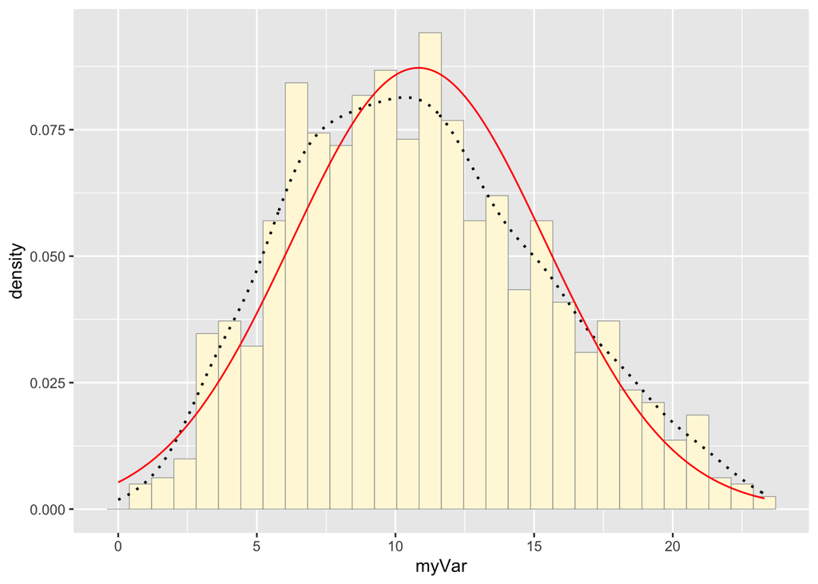

```r
#Plot normal probability density
meanML <- normPars$estimate["mean"]
sdML <- normPars$estimate["sd"]

xval <- seq(0,max(z$myVar),len=length(z$myVar))

stat <- stat_function(aes(x = xval, y = ..y..), fun = dnorm, colour="red", n = length(z$myVar), args = list(mean = m_length, sd = sd_length))
p1 + stat
```

```r
# Assume that each of the treatments follows a normal distribution
# Get maximum likelihood (ML) parameters for normal distribution for each treatment
# First get the maximum likelihood parameters for a normal distribution fitted to these data by calling fitsdir
# Fit normal distributions for each group defined by 'Genotype'

# tapply splits the data in z$Length into subsets based on the values in z$Plant.ID
# Then, it applies the fitdistr() to each subset of data to fit a normal distribution
# norm_pars contains a list of parameter estimates for the normal distribution fitted to the lengths of each plant
# Each element of the list corresponds to a unique value of z$Plant.ID
# parameters of the fitted normal distribution for the corresponding subset of root lengths are stored in each element

# Fit normal distributions for each treatment (genotype/hormone treatment)
# tapply applies a function to subsets of a vector or array, based on one or more factors
norm_pars <- tapply(z$Length, z$Plant.ID, function(x) fitdistr(x, "normal"))
norm_pars <- tapply(z$Length, z$Genotype, function(x) fitdistr(x, "normal"))

# these are rough estimates of root length if using both ACC and genotype
# Save this information for next time :)
# Skip these data and see below for parameter estimates if using JUST genotype

# mean         sd
######### 0nM
# $`1_1_0nM_WT`
# 10.700000    4.472109
# ( 1.999988) ( 1.414205)
# $`1_2_0nM_ccdc22`
# 11.328000    4.436014
# ( 1.983846) ( 1.402791)
# $`1_1_0nM_ccdc93`
# 13.874000    4.813488
# ( 2.152657) ( 1.522158)
# $`1_2_0nM_ccdc22ccdc93`
# 13.704000    5.159452
# ( 2.307377) ( 1.631562)
# $`1_2_0nM_ccdc22RFP`
# 14.682000    5.267760
# ( 2.355814) ( 1.665812)
# $`1_1_0nM_ccdc93RFP`
# 14.800200    5.222040
# ( 2.335368) ( 1.651354)


######### 10nM
# $`1_1_10nM_WT`
# 13.582000    5.310267
# ( 2.374824) ( 1.679254)
# $`1_1_10nM_ccdc22`
# 7.300000   3.756972
# (1.680169) (1.188059)
# $`1_1_10nM_ccdc93`
# 9.972000   3.797154
# (1.698139) (1.200765)
# $`1_1_10nM_ccdc22ccdc93`
# 8.1960000   1.8234100
# (0.8154537) (0.5766129)
# $`1_1_10nM_ccdc22RFP`
# 12.638000    4.624255
# ( 2.068030) ( 1.462318)
# $`1_1_10nM_ccdc93RFP`
# 10.2852000    2.2828781
# ( 1.0209341) ( 0.7219095)

######### 100nM
# $`1_1_100nM_WT`
# 6.7160000   1.9861279
# (0.8882234) (0.6280688)
# $`1_1_100nM_ccdc22`
# 7.6620000   3.1125706
# (1.3919839) (0.9842813)
# $`1_1_100nM_ccdc93`
# 9.5980000   3.1054880
# (1.3888165) (0.9820415)
# $`1_1_100nM_ccdc22ccdc93`
# 9.934000   3.391782
# (1.516851) (1.072576)
# $`1_1_100nM_ccdc22RFP`
# 10.2300000    2.3405384
# ( 1.0467206) ( 0.7401432)
# $`1_1_100nM_ccdc93RFP`
# 7.1680000   1.8515218
# (0.8280257) (0.5855026)

######### 1000nM (1uM)
# $`1_1_1uM_WT`
# 10.0180000    1.8260164
# ( 0.8166194) ( 0.5774371)
# $`1_1_1uM_ccdc22`
# 8.3880000   1.7285069
# (0.7730118) (0.5466019)
# $`1_1_1uM_ccdc93`
# 10.4520000    2.5107003
# ( 1.1228193) ( 0.7939531)
# $`1_1_1uM_ccdc22ccdc93`
# 8.1420000   2.2386013
# (1.0011330) (0.7079079)
# $`1_1_1uM_ccdc22RFP`
# 9.9660000   1.9445884
# (0.8696464) (0.6149328)
# $`1_1_1uM_ccdc93RFP`
# 9.6238000   2.0015200
# (0.8951069) (0.6329362)

# View the ML parameters for each treatment
print(norm_pars)
```

```
## $ccdc22
##      mean         sd
##   9.5992222   4.8467498
##  (0.3612554) (0.2554461)
##
## $ccdc22ccdc93
##       mean          sd
##   10.0921805    4.0788841
##  ( 0.3536841) ( 0.2500924)
##
## $ccdc22RFP
##       mean          sd
##   10.9336154    4.2258974
##  ( 0.3706357) ( 0.2620790)
##
## $ccdc93
##       mean          sd
##   11.3043333    4.7605129
##  ( 0.3548277) ( 0.2509011)
##
## $ccdc93RFP
##       mean          sd
##   10.9235856    4.2714427
##  ( 0.3174938) ( 0.2245020)
##
## $WT
##       mean          sd
##   11.8440500    4.6060560
##  ( 0.3256973) ( 0.2303028)
```

```r
summary(norm_pars)
```

```
##              Length Class    Mode
## ccdc22       5      fitdistr list
## ccdc22ccdc93 5      fitdistr list
## ccdc22RFP    5      fitdistr list
## ccdc93       5      fitdistr list
## ccdc93RFP    5      fitdistr list
## WT           5      fitdistr list
```

```r
# str (norm_pars)...woah!

# These are the ML parameters for genotype only

# $WT
# mean          sd
# 11.8440500    4.6060560
# ( 0.3256973) ( 0.2303028)
#
# $ccdc22
# mean         sd
# 9.5992222   4.8467498
# (0.3612554) (0.2554461)
#
# $ccdc93
# mean          sd
# 11.3043333    4.7605129
# ( 0.3548277) ( 0.2509011)
#
# $ccdc22ccdc93
# mean          sd
# 10.0921805    4.0788841
# ( 0.3536841) ( 0.2500924)
#
# $ccdc22RFP
# mean          sd
# 10.9336154    4.2258974
# ( 0.3706357) ( 0.2620790)
#
# $ccdc93RFP
# mean          sd
# 10.9235856    4.2714427
# ( 0.3174938) ( 0.2245020)

# the data is not set up for this, but it is actually the correct way to analyze this full dataset
# Come back and do the analysis another time after editing dataset
# Need to make treatment its own column and add all three reps
```

# Generate Random Data Set

Using the methods we have covered in class, write code to create a random data set that has these attributes.

*For this analysis, I simplified and fit normal distribution for each genotype only, ignoring the hormone treatment.*

```r
# this set of calls creates individual normal distributions for each variable
rWT <- rnorm(50,11.8,4.6)
mean(rWT)
```

```
## [1] 11.10148
```

```r
sd(rWT)
```

```
## [1] 4.451708
```

```r
r22 <- rnorm(50,9.6,4.8)
mean(r22)
```

```
## [1] 10.29546
```

```r
sd(r22)
```

```
## [1] 4.987135
```

```r
r93 <- rnorm(50,11.3,4.8)
mean(r93)
```

```
## [1] 10.54266
```

```r
sd(r93)
```

```
## [1] 5.278214
```

```r
r2293 <- rnorm(50,10.1,4.1)
mean(r2293)
```

```
## [1] 9.256111
```

```r
sd(r2293)
```

```
## [1] 4.00403
```

```r
r22R <- rnorm(50,10.9,4.2)
mean(r22R)
```

```
## [1] 11.09817
```

```r
sd(r22R)
```

```
## [1] 4.200108
```

```r
r93R <- rnorm(50,10.9,4.3)
mean(r93R)
```

```
## [1] 11.67647
```

```r
sd(r93R)
```

```
## [1] 4.034858
```

```r
# string these into a single vector

resVar <- c(rWT,r22,r93,r2293,r22R,r93R)
#head (resVar)

# associate each response variable with the appropriate genotype, n=50
rGen <- c(rep("WT", 50), rep("CCDC22", 50), rep("CCDC93", 50),
          rep("CCDC22CCDC93", 50), rep("CCDC22RFP", 50),
          rep("CCDC93RFP", 50))

head(rGen)
```

```
## [1] "WT" "WT" "WT" "WT" "WT" "WT"
```

```r
tail(rGen)
```

```
## [1] "CCDC93RFP" "CCDC93RFP" "CCDC93RFP" "CCDC93RFP" "CCDC93RFP" "CCDC93RFP"
```

```r
# this is another way to do the same thing
# rep(nName, each=50)
```

# Create Data Frame

Organize these data into a data frame with the appropriate structure.

*BUT…now that I have written the code above, I don’t think I am actually going to use it. I will create the dataframe and generate the random numbers using the same call from class.*

```r
# Data frame construction for one-way ANOVA
# create a dataframe of random variables

nGroup <- 6 # number of treatment groups
nName <- c("WT","CCDC22", "CCDC93", "CCDC22CCDC93", "CCDC22RFP", "CCDC93RFP") # names of groups
nSize <- c(50,50,50,50,50,50) # number of observations in each group, these are all equal in the simulated dataset
# the mean and variance are estimated using pilot trial numbers

nMean <- c(11.8,9.6,11.3,10.1,10.9,10.9) # mean of each group
nSD <- c(4.6,4.8,4.8,4.1,4.2,4.3) # standard deviation of each group

# id vector for each row, just numbers each row for organization and/or reference
ID <- 1:(sum(nSize))

# create a vector by concatenating six sets of random normal variables
# reVar is the reponse variable, in this case it is root length
resVar <- c(rnorm(n=nSize[1],mean=nMean[1],sd=nSD[1]),
            rnorm(n=nSize[2],mean=nMean[2],sd=nSD[2]),
            rnorm(n=nSize[3],mean=nMean[3],sd=nSD[3]),
            rnorm(n=nSize[4],mean=nMean[4],sd=nSD[4]),
            rnorm(n=nSize[5],mean=nMean[5],sd=nSD[5]),
            rnorm(n=nSize[6],mean=nMean[6],sd=nSD[6]))
# sets up single column with all data, this is now in long form

# create dataframe for downstream ANOVA
TGroup <- rep(nName,nSize)
ANOdata <- data.frame(ID,TGroup,resVar)
str(ANOdata)
```

```
## 'data.frame':    300 obs. of  3 variables:
##  $ ID    : int  1 2 3 4 5 6 7 8 9 10 ...
##  $ TGroup: chr  "WT" "WT" "WT" "WT" ...
##  $ resVar: num  9.98 5.44 8.94 17.75 6.1 ...
```

```r
print(ANOdata) # prints the dataset
```

```
##      ID       TGroup     resVar
## 1     1           WT  9.9758556
## 2     2           WT  5.4370608
## 3     3           WT  8.9362961
## 4     4           WT 17.7510117
## 5     5           WT  6.0956477
## 6     6           WT 25.2752581
## 7     7           WT  9.6735168
## 8     8           WT 18.6562835
## 9     9           WT 15.4997503
## 10   10           WT  9.0746160
## 11   11           WT  8.7878727
## 12   12           WT  6.6250359
## 13   13           WT 11.6391796
## 14   14           WT 12.5838973
```

[output cut: 286 more lines]

# Run ANOVA

Now write code to analyze the data…probably as an ANOVA or regression analysis, but possibly as a logistic regression or contingency table analysis.

```r
# Run basic ANOVA
ANOmodel <- aov(resVar~TGroup,data=ANOdata)
print(ANOmodel)
```

```
## Call:
##    aov(formula = resVar ~ TGroup, data = ANOdata)
##
## Terms:
##                   TGroup Residuals
## Sum of Squares   294.270  5608.833
## Deg. of Freedom        5       294
##
## Residual standard error: 4.367798
## Estimated effects may be unbalanced
```

```r
print(summary(ANOmodel))
```

```
##              Df Sum Sq Mean Sq F value Pr(>F)
## TGroup        5    294   58.85   3.085 0.0099 **
## Residuals   294   5609   19.08
## ---
## Signif. codes:  0 '***' 0.001 '**' 0.01 '*' 0.05 '.' 0.1 ' ' 1
```

```r
z <- summary(ANOmodel)
str(z)
```

```
## List of 1
##  $ :Classes 'anova' and 'data.frame':    2 obs. of  5 variables:
##   ..$ Df     : num [1:2] 5 294
##   ..$ Sum Sq : num [1:2] 294 5609
##   ..$ Mean Sq: num [1:2] 58.9 19.1
##   ..$ F value: num [1:2] 3.08 NA
##   ..$ Pr(>F) : num [1:2] 0.0099 NA
##  - attr(*, "class")= chr [1:2] "summary.aov" "listof"
```

```r
aggregate(resVar~TGroup,data=ANOdata,FUN=mean)
```

```
##         TGroup    resVar
## 1       CCDC22  9.191180
## 2 CCDC22CCDC93  9.839149
## 3    CCDC22RFP 10.944502
## 4       CCDC93 11.492660
## 5    CCDC93RFP 11.396553
## 6           WT 12.032431
```

```r
unlist(z)
```

```
##          Df1          Df2      Sum Sq1      Sum Sq2     Mean Sq1     Mean Sq2
## 5.000000e+00 2.940000e+02 2.942702e+02 5.608833e+03 5.885405e+01 1.907766e+01
##     F value1     F value2      Pr(>F)1      Pr(>F)2
## 3.084972e+00           NA 9.902255e-03           NA
```

```r
unlist(z)[7] # F value1 3.460314
```

```
## F value1
## 3.084972
```

```r
ANOsum <- list(Fval=unlist(z)[7],probF=unlist(z)[9])
ANOsum  # Pr(>F)1     0.004699716
```

```
## $Fval
## F value1
## 3.084972
##
## $probF
##     Pr(>F)1
## 0.009902255
```

# Create a Box Plot

Write code to generate a useful graph of the data.

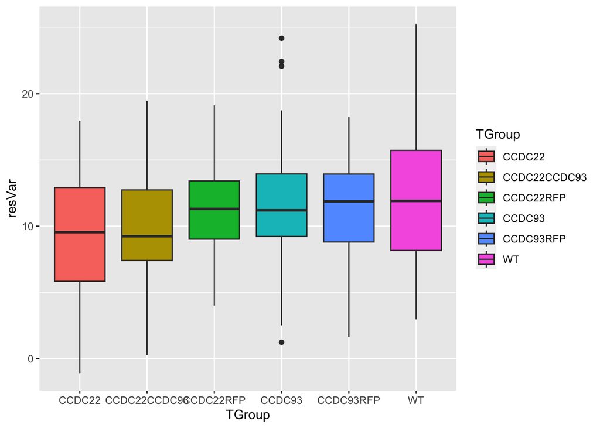

```r
# Use ggplot to visualize the ANOVA data
ANOPlot <- ggplot(data=ANOdata) +
  aes(x=TGroup,y=resVar,fill=TGroup) +
  geom_boxplot()
print(ANOPlot)
```

# Run the Simulation Try running your analysis multiple times to get a feeling for how variable the results are with the same parameters, but different sets of random numbers.

```r
nGroup <- 6 # number of treatment groups
nName <- c("WT","CCDC22", "CCDC93", "CCDC22CCDC93", "CCDC22RFP", "CCDC93RFP") # names of groups
nSize <- c(50,50,50,50,50,50) # number of observations in each group, these are all equal in the simulated dataset
# the mean and variance are estimated using pilot trial numbers

nMean <- c(11.8,9.6,11.3,10.1,10.9,10.9) # mean of each group
nSD <- c(4.6,4.8,4.8,4.1,4.2,4.3) # standard deviation of each group

# id vector for each row, just numbers each row for organization and/or reference
ID <- 1:(sum(nSize))

# create a vector by concatenating six sets of random normal variables
# reVar is the response variable, root length
resVar <- c(rnorm(n=nSize[1],mean=nMean[1],sd=nSD[1]),
            rnorm(n=nSize[2],mean=nMean[2],sd=nSD[2]),
            rnorm(n=nSize[3],mean=nMean[3],sd=nSD[3]),
            rnorm(n=nSize[4],mean=nMean[4],sd=nSD[4]),
            rnorm(n=nSize[5],mean=nMean[5],sd=nSD[5]),
            rnorm(n=nSize[6],mean=nMean[6],sd=nSD[6]))
# sets up single column with all data, this is now in long form

TGroup <- rep(nName,nSize) # TGruop = genotype
ANOdata <- data.frame(ID,TGroup,resVar) # create dataframe
str(ANOdata)
```

```
## 'data.frame':    300 obs. of  3 variables:
##  $ ID    : int  1 2 3 4 5 6 7 8 9 10 ...
##  $ TGroup: chr  "WT" "WT" "WT" "WT" ...
##  $ resVar: num  4.77 13.04 2.21 16.11 9.71 ...
```

```r
# print(ANOdata)

# Run basic ANOVA
# the aggregate function calculates the mean of resVar (root length)for each level
# of TGroup (genotype) in the ANOdata data frame
ANOmodel <- aov(resVar~TGroup,data=ANOdata)
print(ANOmodel)
```

```
## Call:
##    aov(formula = resVar ~ TGroup, data = ANOdata)
##
## Terms:
##                   TGroup Residuals
## Sum of Squares   236.777  6182.343
## Deg. of Freedom        5       294
##
## Residual standard error: 4.585671
## Estimated effects may be unbalanced
```

```r
print(summary(ANOmodel)) # Estimated effects may be unbalanced, not sure if this message is a problem?
```

```
##              Df Sum Sq Mean Sq F value Pr(>F)
## TGroup        5    237   47.36   2.252 0.0493 *
## Residuals   294   6182   21.03
## ---
## Signif. codes:  0 '***' 0.001 '**' 0.01 '*' 0.05 '.' 0.1 ' ' 1
```

```r
z <- summary(ANOmodel)
str(z)
```

```
## List of 1
##  $ :Classes 'anova' and 'data.frame':    2 obs. of  5 variables:
##   ..$ Df     : num [1:2] 5 294
##   ..$ Sum Sq : num [1:2] 237 6182
##   ..$ Mean Sq: num [1:2] 47.4 21
##   ..$ F value: num [1:2] 2.25 NA
##   ..$ Pr(>F) : num [1:2] 0.0493 NA
##  - attr(*, "class")= chr [1:2] "summary.aov" "listof"
```

```r
aggregate(resVar~TGroup,data=ANOdata,FUN=mean)
```

```
##         TGroup   resVar
## 1       CCDC22 10.17855
## 2 CCDC22CCDC93 10.22053
## 3    CCDC22RFP 10.71730
## 4       CCDC93 11.62402
## 5    CCDC93RFP 10.36157
## 6           WT 12.60940
```

```r
unlist(z)
```

```
##          Df1          Df2      Sum Sq1      Sum Sq2     Mean Sq1     Mean Sq2
## 5.000000e+00 2.940000e+02 2.367770e+02 6.182343e+03 4.735540e+01 2.102838e+01
##     F value1     F value2      Pr(>F)1      Pr(>F)2
## 2.251976e+00           NA 4.932409e-02           NA
```

```r
unlist(z)[7] # F value1 multiple run results 3.460314 |1.790044  | 3.486434 | 2.642683 | 1.430171 | 2.554768
```

```
## F value1
## 2.251976
```

```r
ANOsum <- list(Fval=unlist(z)[7],probF=unlist(z)[9])
ANOsum  # Pr(>F)1 multiple run results 0.004699716 | 0.1147189 | 0.004460621 | 0.02346638 | 0.2132236 | 0.02778633
```

```
## $Fval
## F value1
## 2.251976
##
## $probF
##    Pr(>F)1
## 0.04932409
```

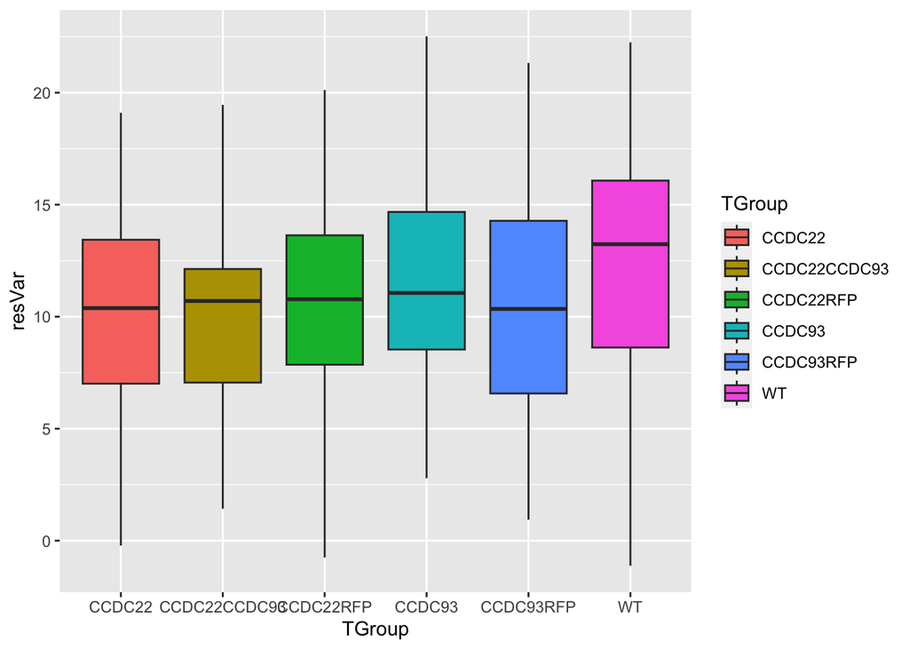

```r
# Pr(>F) p-value associated with the F-statistic
# If Pr(>F) is < 0.05, then at least one of the groups is different

# Use ggplot to visualize the ANOVA data
ANOPlot <- ggplot(data=ANOdata) +
  aes(x=TGroup,y=resVar,fill=TGroup) +
  geom_boxplot()
print(ANOPlot)
```

Commenting out this first method of generating random normal numbers for each genotype separately

```r
# this set of calls creates individual normal distributions for each variable
# rWT <- rnorm(50,11.8,4.6)
# mean(rWT)
# sd(rWT)
#
# r22 <- rnorm(50,9.6,4.8)
# mean(r22)
# sd(r22)
#
# r93 <- rnorm(50,11.3,4.8)
# mean(r93)
# sd(r93)
#
# r2293 <- rnorm(50,10.1,4.1)
# mean(r2293)
# sd(r2293)
#
# r22R <- rnorm(50,10.9,4.2)
# mean(r22R)
# sd(r22R)
#
# r93R <- rnorm(50,10.9,4.3)
# mean(r93R)
# sd(r93R)
#
# # string these into a single vector
#
# resVar <- c(rWT,r22,r93,r2293,r22R,r93R)
# #head (resVar)
#
# # associate each response variable with the appropriate genotype, n=50
# rGen <- c(rep("WT", 50), rep("CCDC22", 50), rep("CCDC93", 50),
#           rep("CCDC22CCDC93", 50), rep("CCDC22RFP", 50),
#           rep("CCDC93RFP", 50))
#
```

# Adjust the Mean and sd to Explore the Experimental Design

Now begin adjusting the means of the different groups. *First, the mean was adjusted to fit the model. Then, the code was run with smaller root length differences to determine how much of a difference is statically different. Finally, the sd was adjusted to an average across all genotypes to determine the effect of variation with each genotype on the outcome.*

```r
# Adjusted Parameters #1: Adjust the mean to fit the expected model.

# Data frame construction for one-way ANOVA
# create a dataframe of random variables

nGroup <- 6 # number of treatment groups
nName <- c("WT","CCDC22", "CCDC93", "CCDC22CCDC93", "CCDC22RFP", "CCDC93RFP") # names of groups
nSize <- c(50,50,50,50,50,50) # number of observations in each group, these are all equal in the simulated dataset
# the mean and variance are estimated using pilot trial numbers

nMean <- c(16,8,8,8,16,16) # adjust the mean of each group
nSD <- c(4.6,4.8,4.8,4.1,4.2,4.3) # leave the standard deviation of each group as estimated by the pilot

# id vector for each row, just numbers each row for organization and/or reference
ID <- 1:(sum(nSize))

# create a vector by concatenating six sets of random normal variables
resVar <- c(rnorm(n=nSize[1],mean=nMean[1],sd=nSD[1]),
            rnorm(n=nSize[2],mean=nMean[2],sd=nSD[2]),
            rnorm(n=nSize[3],mean=nMean[3],sd=nSD[3]),
            rnorm(n=nSize[4],mean=nMean[4],sd=nSD[4]),
            rnorm(n=nSize[5],mean=nMean[5],sd=nSD[5]),
            rnorm(n=nSize[6],mean=nMean[6],sd=nSD[6]))
# sets up single column with all data, this is now in long form

# create dataframe
TGroup <- rep(nName,nSize)
ANOdata <- data.frame(ID,TGroup,resVar)
str(ANOdata)
```

```
## 'data.frame':    300 obs. of  3 variables:
##  $ ID    : int  1 2 3 4 5 6 7 8 9 10 ...
##  $ TGroup: chr  "WT" "WT" "WT" "WT" ...
##  $ resVar: num  16.6 24 20.6 14.9 11.5 ...
```

```r
# print(ANOdata)

# Run basic ANOVA
ANOmodel <- aov(resVar~TGroup,data=ANOdata)
print(ANOmodel)
```

```
## Call:
##    aov(formula = resVar ~ TGroup, data = ANOdata)
##
## Terms:
##                   TGroup Residuals
## Sum of Squares  5186.673  5736.466
## Deg. of Freedom        5       294
##
## Residual standard error: 4.417215
## Estimated effects may be unbalanced
```

```r
print(summary(ANOmodel))
```

```
##              Df Sum Sq Mean Sq F value Pr(>F)
## TGroup        5   5187  1037.3   53.16 <2e-16 ***
## Residuals   294   5736    19.5
## ---
## Signif. codes:  0 '***' 0.001 '**' 0.01 '*' 0.05 '.' 0.1 ' ' 1
```

```r
z <- summary(ANOmodel)
str(z)
```

```
## List of 1
##  $ :Classes 'anova' and 'data.frame':    2 obs. of  5 variables:
##   ..$ Df     : num [1:2] 5 294
##   ..$ Sum Sq : num [1:2] 5187 5736
##   ..$ Mean Sq: num [1:2] 1037.3 19.5
##   ..$ F value: num [1:2] 53.2 NA
##   ..$ Pr(>F) : num [1:2] 3.44e-39 NA
##  - attr(*, "class")= chr [1:2] "summary.aov" "listof"
```

```r
aggregate(resVar~TGroup,data=ANOdata,FUN=mean)
```

```
##         TGroup    resVar
## 1       CCDC22  7.232085
## 2 CCDC22CCDC93  8.120326
## 3    CCDC22RFP 16.553966
## 4       CCDC93  9.167639
## 5    CCDC93RFP 16.456054
## 6           WT 16.224242
```

```r
unlist(z)
```

```
##          Df1          Df2      Sum Sq1      Sum Sq2     Mean Sq1     Mean Sq2
## 5.000000e+00 2.940000e+02 5.186673e+03 5.736466e+03 1.037335e+03 1.951179e+01
##     F value1     F value2      Pr(>F)1      Pr(>F)2
## 5.316450e+01           NA 3.437000e-39           NA
```

```r
unlist(z)[7] # F value1 3.460314
```

```
## F value1
##  53.1645
```

```r
ANOsum <- list(Fval=unlist(z)[7],probF=unlist(z)[9])
ANOsum  # Pr(>F)1     0.004699716
```

```
## $Fval
## F value1
##  53.1645
##
## $probF
##   Pr(>F)1
## 3.437e-39
```

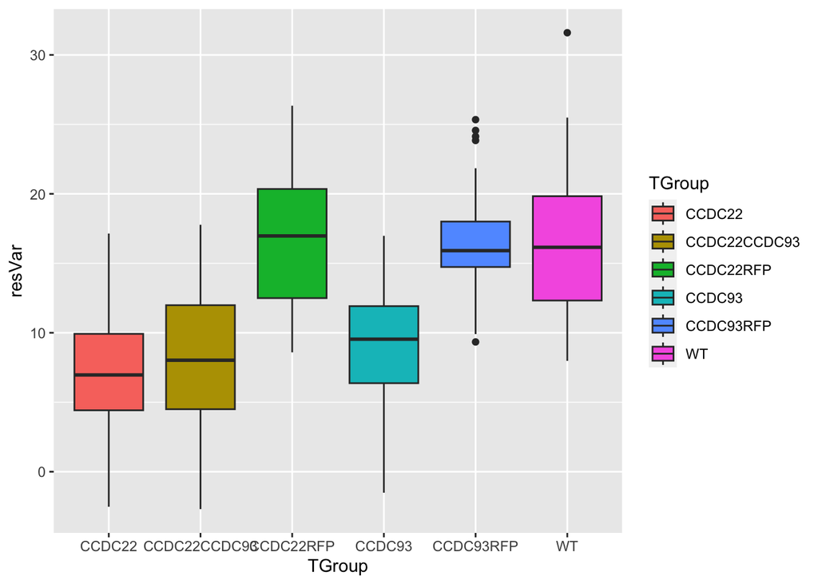

```r
# Pr(>F) p-value associated with the F-statistic
# If Pr(>F) is < 0.05, then at least one of the groups is different

# Use ggplot to visualize the ANOVA data
ANOPlot <- ggplot(data=ANOdata) +
  aes(x=TGroup,y=resVar,fill=TGroup) +
  geom_boxplot()
print(ANOPlot)
```

```r
# Adjusted Parameters #2: Does a smaller (2mm) mean root length difference still generate significant values?

nGroup <- 6 # number of treatment groups
nName <- c("WT","CCDC22", "CCDC93", "CCDC22CCDC93", "CCDC22RFP", "CCDC93RFP") # names of groups
nSize <- c(50,50,50,50,50,50) # number of observations in each group, these are all equal in the simulated dataset
# the mean and variance are estimated using pilot trial numbers

nMean <- c(10,8,8,8,10,10) # adjust the mean of each group
nSD <- c(4.6,4.8,4.8,4.1,4.2,4.3) # leave the standard deviation of each group as estimated by the pilot

# id vector for each row, just numbers each row for organization and/or reference
ID <- 1:(sum(nSize))

# create a vector by concatenating six sets of random normal variables
resVar <- c(rnorm(n=nSize[1],mean=nMean[1],sd=nSD[1]),
            rnorm(n=nSize[2],mean=nMean[2],sd=nSD[2]),
            rnorm(n=nSize[3],mean=nMean[3],sd=nSD[3]),
            rnorm(n=nSize[4],mean=nMean[4],sd=nSD[4]),
            rnorm(n=nSize[5],mean=nMean[5],sd=nSD[5]),
            rnorm(n=nSize[6],mean=nMean[6],sd=nSD[6]))
# sets up single column with all data, this is now in long form

# create dataframe
TGroup <- rep(nName,nSize)
ANOdata <- data.frame(ID,TGroup,resVar)
str(ANOdata)
```

```
## 'data.frame':    300 obs. of  3 variables:
##  $ ID    : int  1 2 3 4 5 6 7 8 9 10 ...
##  $ TGroup: chr  "WT" "WT" "WT" "WT" ...
##  $ resVar: num  8.72 7.11 15.92 16.99 3.38 ...
```

```r
# print(ANOdata)

# Run basic ANOVA
ANOmodel <- aov(resVar~TGroup,data=ANOdata)
print(ANOmodel)
```

```
## Call:
##    aov(formula = resVar ~ TGroup, data = ANOdata)
##
## Terms:
##                   TGroup Residuals
## Sum of Squares   217.252  6300.366
## Deg. of Freedom        5       294
##
## Residual standard error: 4.629235
## Estimated effects may be unbalanced
```

```r
print(summary(ANOmodel))
```

```
##              Df Sum Sq Mean Sq F value Pr(>F)
## TGroup        5    217   43.45   2.028 0.0747 .
## Residuals   294   6300   21.43
## ---
## Signif. codes:  0 '***' 0.001 '**' 0.01 '*' 0.05 '.' 0.1 ' ' 1
```

```r
z <- summary(ANOmodel)
str(z)
```

```
## List of 1
##  $ :Classes 'anova' and 'data.frame':    2 obs. of  5 variables:
##   ..$ Df     : num [1:2] 5 294
##   ..$ Sum Sq : num [1:2] 217 6300
##   ..$ Mean Sq: num [1:2] 43.5 21.4
##   ..$ F value: num [1:2] 2.03 NA
##   ..$ Pr(>F) : num [1:2] 0.0747 NA
##  - attr(*, "class")= chr [1:2] "summary.aov" "listof"
```

```r
aggregate(resVar~TGroup,data=ANOdata,FUN=mean)
```

```
##         TGroup    resVar
## 1       CCDC22  8.808014
## 2 CCDC22CCDC93  8.271451
## 3    CCDC22RFP 10.382082
## 4       CCDC93  9.272577
## 5    CCDC93RFP  9.916025
## 6           WT 10.670974
```

```r
unlist(z)
```

```
##          Df1          Df2      Sum Sq1      Sum Sq2     Mean Sq1     Mean Sq2
## 5.000000e+00 2.940000e+02 2.172517e+02 6.300366e+03 4.345035e+01 2.142982e+01
##     F value1     F value2      Pr(>F)1      Pr(>F)2
## 2.027565e+00           NA 7.473915e-02           NA
```

```r
unlist(z)[7] # F value1 of multiple runs  3.460314 | 3.057447 | 4.37688
```

```
## F value1
## 2.027565
```

```r
ANOsum <- list(Fval=unlist(z)[7],probF=unlist(z)[9])
ANOsum  # Pr(>F)1 of multiple runs 0.004699716 | 0.01045411 | 0.0007376741
```

```
## $Fval
## F value1
## 2.027565
##
## $probF
##    Pr(>F)1
## 0.07473915
```

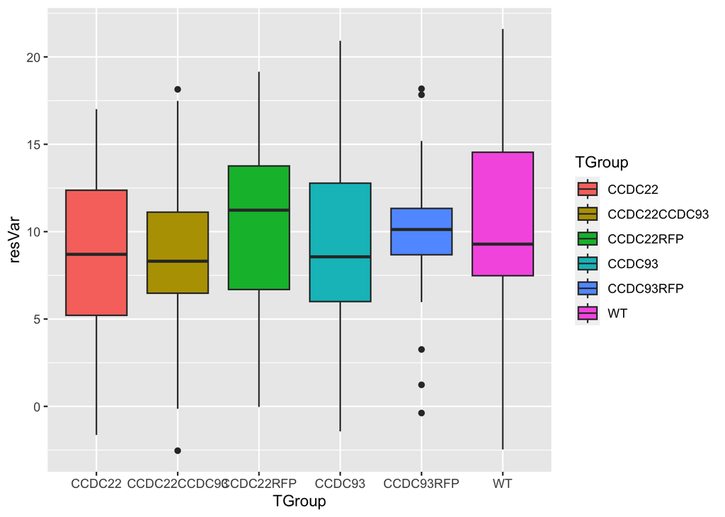

```r
# Pr(>F) p-value associated with the F-statistic
# If Pr(>F) is < 0.05, then at least one of the groups is different

# Use ggplot to visualize the ANOVA data
ANOPlot <- ggplot(data=ANOdata) +
  aes(x=TGroup,y=resVar,fill=TGroup) +
  geom_boxplot()
print(ANOPlot)
```

```r
# Adjusted Parameters #3: Does an even smaller difference (1mm) in mean root length still generate significant values?

nGroup <- 6 # number of treatment groups
nName <- c("WT","CCDC22", "CCDC93", "CCDC22CCDC93", "CCDC22RFP", "CCDC93RFP") # names of groups
nSize <- c(50,50,50,50,50,50) # number of observations in each group, these are all equal in the simulated dataset
# the mean and variance are estimated using pilot trial numbers

nMean <- c(10,9,9,9,10,10) # adjust the mean of each group
nSD <- c(4.6,4.8,4.8,4.1,4.2,4.3) # leave the standard deviation of each group as estimated by the pilot

# id vector for each row, just numbers each row for organization and/or reference
ID <- 1:(sum(nSize))

# create a vector by concatenating six sets of random normal variables
resVar <- c(rnorm(n=nSize[1],mean=nMean[1],sd=nSD[1]),
            rnorm(n=nSize[2],mean=nMean[2],sd=nSD[2]),
            rnorm(n=nSize[3],mean=nMean[3],sd=nSD[3]),
            rnorm(n=nSize[4],mean=nMean[4],sd=nSD[4]),
            rnorm(n=nSize[5],mean=nMean[5],sd=nSD[5]),
            rnorm(n=nSize[6],mean=nMean[6],sd=nSD[6]))
# sets up single column with all data, this is now in long form

# create dataframe
TGroup <- rep(nName,nSize)
ANOdata <- data.frame(ID,TGroup,resVar)
str(ANOdata)
```

```
## 'data.frame':    300 obs. of  3 variables:
##  $ ID    : int  1 2 3 4 5 6 7 8 9 10 ...
##  $ TGroup: chr  "WT" "WT" "WT" "WT" ...
##  $ resVar: num  10.47 12.56 7.47 10.09 16.78 ...
```

```r
# print(ANOdata)

# Run basic ANOVA
ANOmodel <- aov(resVar~TGroup,data=ANOdata)
print(ANOmodel)
```

```
## Call:
##    aov(formula = resVar ~ TGroup, data = ANOdata)
##
## Terms:
##                   TGroup Residuals
## Sum of Squares   298.139  6068.379
## Deg. of Freedom        5       294
##
## Residual standard error: 4.543208
## Estimated effects may be unbalanced
```

```r
print(summary(ANOmodel))
```

```
##              Df Sum Sq Mean Sq F value Pr(>F)
## TGroup        5    298   59.63   2.889 0.0146 *
## Residuals   294   6068   20.64
## ---
## Signif. codes:  0 '***' 0.001 '**' 0.01 '*' 0.05 '.' 0.1 ' ' 1
```

```r
z <- summary(ANOmodel)
str(z)
```

```
## List of 1
##  $ :Classes 'anova' and 'data.frame':    2 obs. of  5 variables:
##   ..$ Df     : num [1:2] 5 294
##   ..$ Sum Sq : num [1:2] 298 6068
##   ..$ Mean Sq: num [1:2] 59.6 20.6
##   ..$ F value: num [1:2] 2.89 NA
##   ..$ Pr(>F) : num [1:2] 0.0146 NA
##  - attr(*, "class")= chr [1:2] "summary.aov" "listof"
```

```r
aggregate(resVar~TGroup,data=ANOdata,FUN=mean)
```

```
##         TGroup    resVar
## 1       CCDC22  8.876861
## 2 CCDC22CCDC93  8.932620
## 3    CCDC22RFP 10.058849
## 4       CCDC93  7.518349
## 5    CCDC93RFP  9.829588
## 6           WT 10.572078
```

```r
unlist(z)
```

```
##          Df1          Df2      Sum Sq1      Sum Sq2     Mean Sq1     Mean Sq2
##    5.0000000  294.0000000  298.1386336 6068.3785376   59.6277267   20.6407433
##     F value1     F value2      Pr(>F)1      Pr(>F)2
##    2.8888362           NA    0.0145525           NA
```

```r
unlist(z)[7] # F value1 of multiple runs  0.8566817 | 2.737496 | 2.725934
```

```
## F value1
## 2.888836
```

```r
ANOsum <- list(Fval=unlist(z)[7],probF=unlist(z)[9])
ANOsum  # Pr(>F)1 of multiple runs 0.5106597 | 0.01953694 | 0.01997955
```

```
## $Fval
## F value1
## 2.888836
##
## $probF
##   Pr(>F)1
## 0.0145525
```

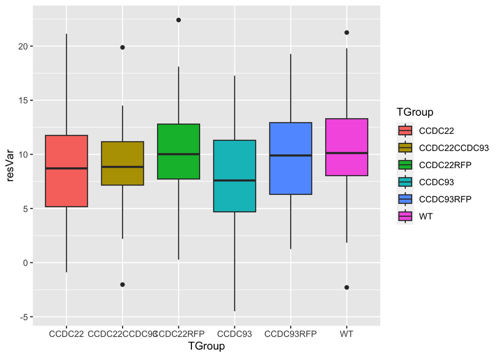

```r
# Pr(>F) p-value associated with the F-statistic
# If Pr(>F) is < 0.05, then at least one of the groups is different

# Use ggplot to visualize the ANOVA data
ANOPlot <- ggplot(data=ANOdata) +
  aes(x=TGroup,y=resVar,fill=TGroup) +
  geom_boxplot()
print(ANOPlot)
```

```r
# Adjusted Parameters #4: Set the variation within genotypes as a constant.

# Data frame construction for one-way ANOVA
# create a dataframe of random variables

nGroup <- 6 # number of treatment groups
nName <- c("WT","CCDC22", "CCDC93", "CCDC22CCDC93", "CCDC22RFP", "CCDC93RFP") # names of groups
nSize <- c(50,50,50,50,50,50) # number of observations in each group, these are all equal in the simulated dataset
# the mean and variance are estimated using pilot trial numbers

nMean <- c(11.8,9.6,11.3,10.1,10.9,10.9) # original means
nSD <- c(4.5,4.5,4.5,4.5,4.5,4.5) # set the standard deviation as a constant across all genotypes

# id vector for each row, just numbers each row for organization and/or reference
ID <- 1:(sum(nSize))

# create a vector by concatenating six sets of random normal variables
resVar <- c(rnorm(n=nSize[1],mean=nMean[1],sd=nSD[1]),
            rnorm(n=nSize[2],mean=nMean[2],sd=nSD[2]),
            rnorm(n=nSize[3],mean=nMean[3],sd=nSD[3]),
            rnorm(n=nSize[4],mean=nMean[4],sd=nSD[4]),
            rnorm(n=nSize[5],mean=nMean[5],sd=nSD[5]),
            rnorm(n=nSize[6],mean=nMean[6],sd=nSD[6]))
# sets up single column with all data, this is now in long form

# create dataframe
TGroup <- rep(nName,nSize)
ANOdata <- data.frame(ID,TGroup,resVar)
str(ANOdata)
```

```
## 'data.frame':    300 obs. of  3 variables:
##  $ ID    : int  1 2 3 4 5 6 7 8 9 10 ...
##  $ TGroup: chr  "WT" "WT" "WT" "WT" ...
##  $ resVar: num  12.43 1.53 14.93 10.43 11.39 ...
```

```r
# print(ANOdata)

# Run basic ANOVA
ANOmodel <- aov(resVar~TGroup,data=ANOdata)
print(ANOmodel)
```

```
## Call:
##    aov(formula = resVar ~ TGroup, data = ANOdata)
##
## Terms:
##                   TGroup Residuals
## Sum of Squares   253.812  6061.595
## Deg. of Freedom        5       294
##
## Residual standard error: 4.540669
## Estimated effects may be unbalanced
```

```r
print(summary(ANOmodel))
```

```
##              Df Sum Sq Mean Sq F value Pr(>F)
## TGroup        5    254   50.76   2.462 0.0332 *
## Residuals   294   6062   20.62
## ---
## Signif. codes:  0 '***' 0.001 '**' 0.01 '*' 0.05 '.' 0.1 ' ' 1
```

```r
z <- summary(ANOmodel)
str(z)
```

```
## List of 1
##  $ :Classes 'anova' and 'data.frame':    2 obs. of  5 variables:
##   ..$ Df     : num [1:2] 5 294
##   ..$ Sum Sq : num [1:2] 254 6062
##   ..$ Mean Sq: num [1:2] 50.8 20.6
##   ..$ F value: num [1:2] 2.46 NA
##   ..$ Pr(>F) : num [1:2] 0.0332 NA
##  - attr(*, "class")= chr [1:2] "summary.aov" "listof"
```

```r
aggregate(resVar~TGroup,data=ANOdata,FUN=mean)
```

```
##         TGroup    resVar
## 1       CCDC22  9.235693
## 2 CCDC22CCDC93 10.840318
## 3    CCDC22RFP 10.772947
## 4       CCDC93 11.873522
## 5    CCDC93RFP  9.330270
## 6           WT 10.705779
```

```r
unlist(z)
```

```
##          Df1          Df2      Sum Sq1      Sum Sq2     Mean Sq1     Mean Sq2
## 5.000000e+00 2.940000e+02 2.538123e+02 6.061595e+03 5.076247e+01 2.061767e+01
##     F value1     F value2      Pr(>F)1      Pr(>F)2
## 2.462085e+00           NA 3.316863e-02           NA
```

```r
unlist(z)[7] # F value1 of multiple runs  1.183123 | 4.613077
```

```
## F value1
## 2.462085
```

```r
ANOsum <- list(Fval=unlist(z)[7],probF=unlist(z)[9])
ANOsum  # Pr(>F)1 of multiple runs  0.3174042 | 0.0004555719
```

```
## $Fval
## F value1
## 2.462085
##
## $probF
##    Pr(>F)1
## 0.03316863
```

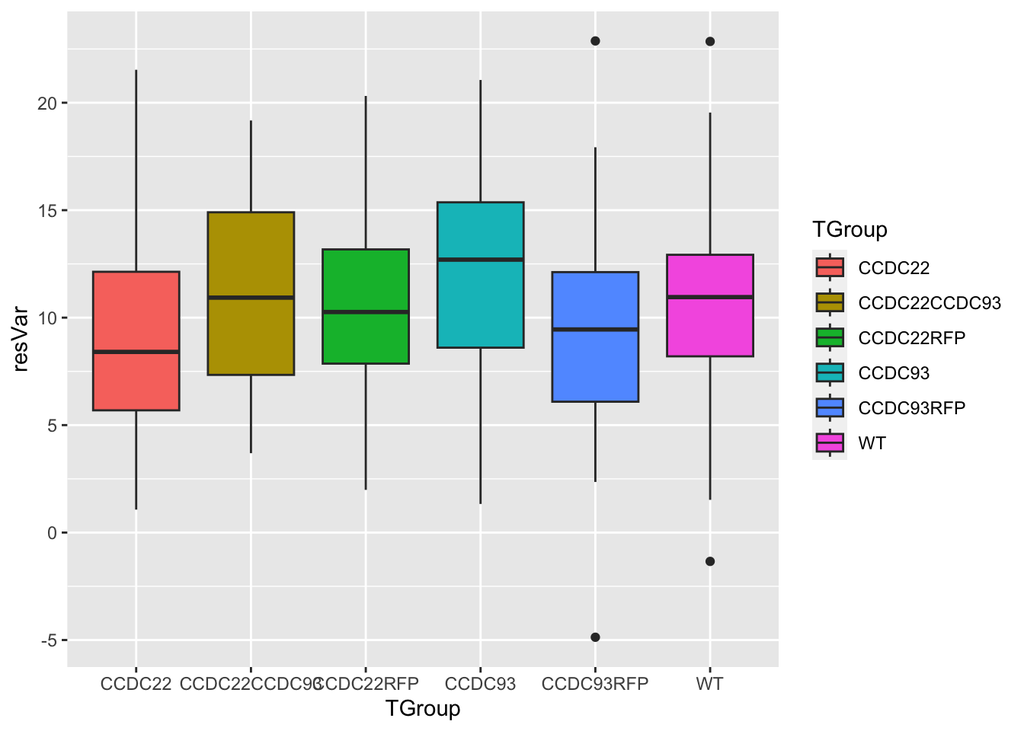

```r
# Pr(>F) p-value associated with the F-statistic
# If Pr(>F) is < 0.05, then at least one of the groups is different
# adjusting the sd seems to result in the data more more often failing to reject the null

# Use ggplot to visualize the ANOVA data
ANOPlot <- ggplot(data=ANOdata) +
  aes(x=TGroup,y=resVar,fill=TGroup) +
  geom_boxplot()
print(ANOPlot)
```

Given the sample sizes you have chosen, how small can the differences between the groups be (the “effect size”) for you to still detect a significant pattern (p < 0.05)?

*My understanding is that it is valuable to look at both the F-value and the p-value. The F-value is used to test the null hypothesis that the means of several groups are equal. In this case that means that all genotypes have the same root length. If the F-value is large and the associated p-value is small (P < 0.05), it suggests that there is a significant difference between the means of at least two groups.*

# Explore Sample Size

Alternatively, for the effect sizes you originally hypothesized, what is the minimum sample size you would need in order to detect a statistically significant effect? Again, run the model a few times with the same parameter set to get a feeling for the effect of random variation in the data.

```r
################################
# Adjust sample size to n=10
################################

nGroup <- 6 # number of treatment groups
nName <- c("WT","CCDC22", "CCDC93", "CCDC22CCDC93", "CCDC22RFP", "CCDC93RFP") # names of groups
nSize <- c(10,10,10,10,10,10) # number of observations in each group, these are all equal in the simulated dataset
# the mean and variance are estimated using pilot trial numbers

nMean <- c(11.8,9.6,11.3,10.1,10.9,10.9) # mean of each group
nSD <- c(4.6,4.8,4.8,4.1,4.2,4.3) # standard deviation of each group

# id vector for each row, just numbers each row for organization and/or reference
ID <- 1:(sum(nSize))

# create a vector by concatenating six sets of random normal variables
# reVar is the response variable, root length
resVar <- c(rnorm(n=nSize[1],mean=nMean[1],sd=nSD[1]),
            rnorm(n=nSize[2],mean=nMean[2],sd=nSD[2]),
            rnorm(n=nSize[3],mean=nMean[3],sd=nSD[3]),
            rnorm(n=nSize[4],mean=nMean[4],sd=nSD[4]),
            rnorm(n=nSize[5],mean=nMean[5],sd=nSD[5]),
            rnorm(n=nSize[6],mean=nMean[6],sd=nSD[6]))
# sets up single column with all data, this is now in long form

TGroup <- rep(nName,nSize) # TGruop = genotype
ANOdata <- data.frame(ID,TGroup,resVar) # create dataframe
str(ANOdata)
```

```
## 'data.frame':    60 obs. of  3 variables:
##  $ ID    : int  1 2 3 4 5 6 7 8 9 10 ...
##  $ TGroup: chr  "WT" "WT" "WT" "WT" ...
##  $ resVar: num  4.862 5.256 19.534 -0.627 11.979 ...
```

```r
# print(ANOdata)

# Run basic ANOVA
# the aggregate function calculates the mean of resVar (root length)for each level
# of TGroup (genotype) in the ANOdata data frame
ANOmodel <- aov(resVar~TGroup,data=ANOdata)
print(ANOmodel)
```

```
## Call:
##    aov(formula = resVar ~ TGroup, data = ANOdata)
##
## Terms:
##                    TGroup Residuals
## Sum of Squares   137.2724 1328.7207
## Deg. of Freedom         5        54
##
## Residual standard error: 4.960437
## Estimated effects may be unbalanced
```

```r
print(summary(ANOmodel)) # Estimated effects may be unbalanced, not sure if this message is a problem?
```

```
##             Df Sum Sq Mean Sq F value Pr(>F)
## TGroup       5  137.3   27.45   1.116  0.363
## Residuals   54 1328.7   24.61
```

```r
z <- summary(ANOmodel)
str(z)
```

```
## List of 1
##  $ :Classes 'anova' and 'data.frame':    2 obs. of  5 variables:
##   ..$ Df     : num [1:2] 5 54
##   ..$ Sum Sq : num [1:2] 137 1329
##   ..$ Mean Sq: num [1:2] 27.5 24.6
##   ..$ F value: num [1:2] 1.12 NA
##   ..$ Pr(>F) : num [1:2] 0.363 NA
##  - attr(*, "class")= chr [1:2] "summary.aov" "listof"
```

```r
aggregate(resVar~TGroup,data=ANOdata,FUN=mean)
```

```
##         TGroup    resVar
## 1       CCDC22  7.843266
## 2 CCDC22CCDC93 10.425059
## 3    CCDC22RFP 11.747775
## 4       CCDC93 12.731492
## 5    CCDC93RFP 11.209760
## 6           WT 10.551695
```

```r
unlist(z)
```

```
##          Df1          Df2      Sum Sq1      Sum Sq2     Mean Sq1     Mean Sq2
##    5.0000000   54.0000000  137.2724415 1328.7206886   27.4544883   24.6059387
##     F value1     F value2      Pr(>F)1      Pr(>F)2
##    1.1157668           NA    0.3630387           NA
```

```r
unlist(z)[7]
```

```
## F value1
## 1.115767
```

```r
ANOsum <- list(Fval=unlist(z)[7],probF=unlist(z)[9])
ANOsum
```

```
## $Fval
## F value1
## 1.115767
##
## $probF
##   Pr(>F)1
## 0.3630387
```

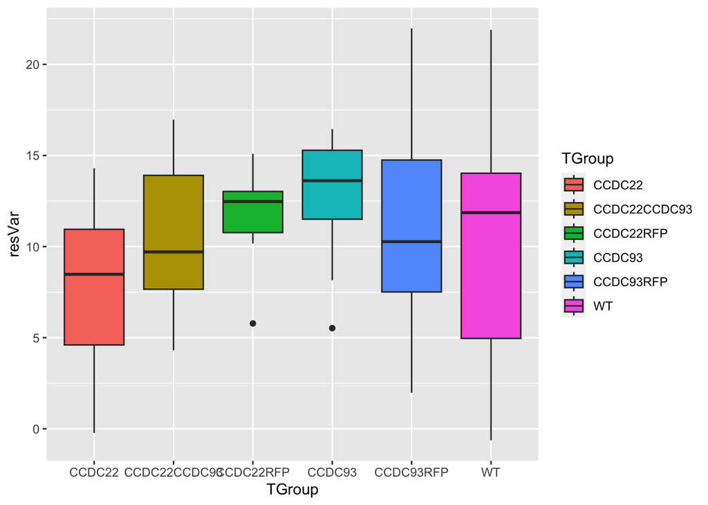

```r
# Pr(>F) p-value associated with the F-statistic
# If Pr(>F) is < 0.05, then at least one of the groups is different
# Multiple run results
#  F value1
# 0.3651354 | 0.7483566 | 1.354049
#   Pr(>F)1
# 0.8701885 | 0.5908783 | 0.2561594


# Use ggplot to visualize the ANOVA data
ANOPlot <- ggplot(data=ANOdata) +
  aes(x=TGroup,y=resVar,fill=TGroup) +
  geom_boxplot()
print(ANOPlot)
```

```r
################################
# Adjust sample size to n=20
################################

nGroup <- 6 # number of treatment groups
nName <- c("WT","CCDC22", "CCDC93", "CCDC22CCDC93", "CCDC22RFP", "CCDC93RFP") # names of groups
nSize <- c(20,20,20,20,20,20) # number of observations in each group, these are all equal in the simulated dataset
# the mean and variance are estimated using pilot trial numbers

nMean <- c(11.8,9.6,11.3,10.1,10.9,10.9) # mean of each group
nSD <- c(4.6,4.8,4.8,4.1,4.2,4.3) # standard deviation of each group

# id vector for each row, just numbers each row for organization and/or reference
ID <- 1:(sum(nSize))

# create a vector by concatenating six sets of random normal variables
# reVar is the response variable, root length
resVar <- c(rnorm(n=nSize[1],mean=nMean[1],sd=nSD[1]),
            rnorm(n=nSize[2],mean=nMean[2],sd=nSD[2]),
            rnorm(n=nSize[3],mean=nMean[3],sd=nSD[3]),
            rnorm(n=nSize[4],mean=nMean[4],sd=nSD[4]),
            rnorm(n=nSize[5],mean=nMean[5],sd=nSD[5]),
            rnorm(n=nSize[6],mean=nMean[6],sd=nSD[6]))
# sets up single column with all data, this is now in long form

TGroup <- rep(nName,nSize) # TGruop = genotype
ANOdata <- data.frame(ID,TGroup,resVar) # create dataframe
str(ANOdata)
```

```
## 'data.frame':    120 obs. of  3 variables:
##  $ ID    : int  1 2 3 4 5 6 7 8 9 10 ...
##  $ TGroup: chr  "WT" "WT" "WT" "WT" ...
##  $ resVar: num  11.9 6.26 9.52 5.55 8.26 ...
```

```r
# print(ANOdata)

# Run basic ANOVA
# the aggregate function calculates the mean of resVar (root length)for each level
# of TGroup (genotype) in the ANOdata data frame
ANOmodel <- aov(resVar~TGroup,data=ANOdata)
print(ANOmodel)
```

```
## Call:
##    aov(formula = resVar ~ TGroup, data = ANOdata)
##
## Terms:
##                   TGroup Residuals
## Sum of Squares   218.053  1869.849
## Deg. of Freedom        5       114
##
## Residual standard error: 4.049961
## Estimated effects may be unbalanced
```

```r
print(summary(ANOmodel)) # Estimated effects may be unbalanced, not sure if this message is a problem?
```

```
##              Df Sum Sq Mean Sq F value Pr(>F)
## TGroup        5  218.1   43.61   2.659  0.026 *
## Residuals   114 1869.8   16.40
## ---
## Signif. codes:  0 '***' 0.001 '**' 0.01 '*' 0.05 '.' 0.1 ' ' 1
```

```r
z <- summary(ANOmodel)
str(z)
```

```
## List of 1
##  $ :Classes 'anova' and 'data.frame':    2 obs. of  5 variables:
##   ..$ Df     : num [1:2] 5 114
##   ..$ Sum Sq : num [1:2] 218 1870
##   ..$ Mean Sq: num [1:2] 43.6 16.4
##   ..$ F value: num [1:2] 2.66 NA
##   ..$ Pr(>F) : num [1:2] 0.026 NA
##  - attr(*, "class")= chr [1:2] "summary.aov" "listof"
```

```r
aggregate(resVar~TGroup,data=ANOdata,FUN=mean)
```

```
##         TGroup    resVar
## 1       CCDC22 10.787662
## 2 CCDC22CCDC93 10.494656
## 3    CCDC22RFP 11.015392
## 4       CCDC93  8.558141
## 5    CCDC93RFP 13.179577
## 6           WT 10.507484
```

```r
unlist(z)
```

```
##          Df1          Df2      Sum Sq1      Sum Sq2     Mean Sq1     Mean Sq2
## 5.000000e+00 1.140000e+02 2.180530e+02 1.869849e+03 4.361060e+01 1.640218e+01
##     F value1     F value2      Pr(>F)1      Pr(>F)2
## 2.658829e+00           NA 2.596655e-02           NA
```

```r
unlist(z)[7]
```

```
## F value1
## 2.658829
```

```r
ANOsum <- list(Fval=unlist(z)[7],probF=unlist(z)[9])
ANOsum
```

```
## $Fval
## F value1
## 2.658829
##
## $probF
##    Pr(>F)1
## 0.02596655
```

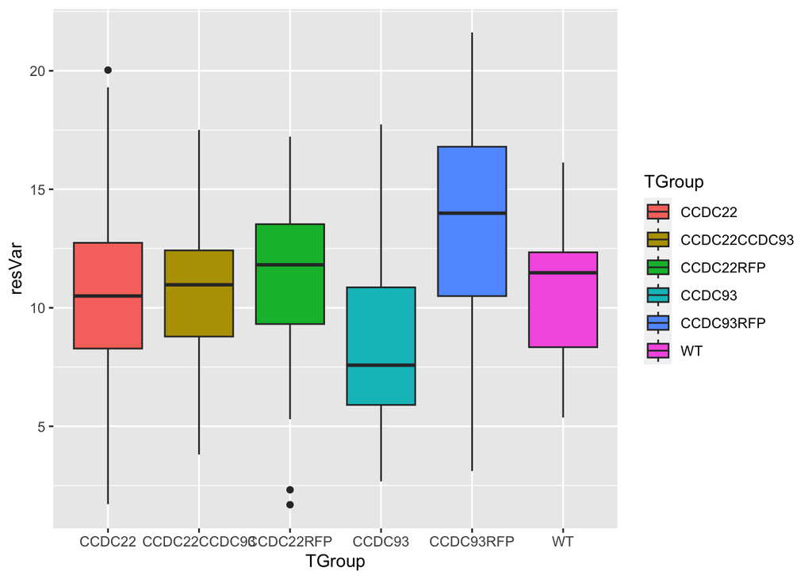

```r
# Pr(>F) p-value associated with the F-statistic
# If Pr(>F) is < 0.05, then at least one of the groups is different
# Multiple run results
#  F value1
# 4.254324 | 2.351236  | 1.051566
#   Pr(>F)1
# 0.001388849  | 0.04514597 | 0.3911177

# Use ggplot to visualize the ANOVA data
ANOPlot <- ggplot(data=ANOdata) +
  aes(x=TGroup,y=resVar,fill=TGroup) +
  geom_boxplot()
print(ANOPlot)
```

```r
################################
# Adjust sample size to n=75
################################

nGroup <- 6 # number of treatment groups
nName <- c("WT","CCDC22", "CCDC93", "CCDC22CCDC93", "CCDC22RFP", "CCDC93RFP") # names of groups
nSize <- c(75,75,75,75,75,75) # number of observations in each group, these are all equal in the simulated dataset
# the mean and variance are estimated using pilot trial numbers

nMean <- c(11.8,9.6,11.3,10.1,10.9,10.9) # mean of each group
nSD <- c(4.6,4.8,4.8,4.1,4.2,4.3) # standard deviation of each group

# id vector for each row, just numbers each row for organization and/or reference
ID <- 1:(sum(nSize))

# create a vector by concatenating six sets of random normal variables
# reVar is the response variable, root length
resVar <- c(rnorm(n=nSize[1],mean=nMean[1],sd=nSD[1]),
            rnorm(n=nSize[2],mean=nMean[2],sd=nSD[2]),
            rnorm(n=nSize[3],mean=nMean[3],sd=nSD[3]),
            rnorm(n=nSize[4],mean=nMean[4],sd=nSD[4]),
            rnorm(n=nSize[5],mean=nMean[5],sd=nSD[5]),
            rnorm(n=nSize[6],mean=nMean[6],sd=nSD[6]))
# sets up single column with all data, this is now in long form

TGroup <- rep(nName,nSize) # TGruop = genotype
ANOdata <- data.frame(ID,TGroup,resVar) # create dataframe
str(ANOdata)
```

```
## 'data.frame':    450 obs. of  3 variables:
##  $ ID    : int  1 2 3 4 5 6 7 8 9 10 ...
##  $ TGroup: chr  "WT" "WT" "WT" "WT" ...
##  $ resVar: num  20.32 23.45 9.51 20.81 15.49 ...
```

```r
# print(ANOdata)

# Run basic ANOVA
# the aggregate function calculates the mean of resVar (root length)for each level
# of TGroup (genotype) in the ANOdata data frame
ANOmodel <- aov(resVar~TGroup,data=ANOdata)
print(ANOmodel)
```

```
## Call:
##    aov(formula = resVar ~ TGroup, data = ANOdata)
##
## Terms:
##                   TGroup Residuals
## Sum of Squares    66.390  8306.311
## Deg. of Freedom        5       444
##
## Residual standard error: 4.325264
## Estimated effects may be unbalanced
```

```r
print(summary(ANOmodel)) # Estimated effects may be unbalanced, not sure if this message is a problem?
```

```
##              Df Sum Sq Mean Sq F value Pr(>F)
## TGroup        5     66   13.28    0.71  0.616
## Residuals   444   8306   18.71
```

```r
z <- summary(ANOmodel)
str(z)
```

```
## List of 1
##  $ :Classes 'anova' and 'data.frame':    2 obs. of  5 variables:
##   ..$ Df     : num [1:2] 5 444
##   ..$ Sum Sq : num [1:2] 66.4 8306.3
##   ..$ Mean Sq: num [1:2] 13.3 18.7
##   ..$ F value: num [1:2] 0.71 NA
##   ..$ Pr(>F) : num [1:2] 0.616 NA
##  - attr(*, "class")= chr [1:2] "summary.aov" "listof"
```

```r
aggregate(resVar~TGroup,data=ANOdata,FUN=mean)
```

```
##         TGroup   resVar
## 1       CCDC22 10.64800
## 2 CCDC22CCDC93 10.57785
## 3    CCDC22RFP 11.50664
## 4       CCDC93 11.50676
## 5    CCDC93RFP 10.99478
## 6           WT 11.35767
```

```r
unlist(z)
```

```
##          Df1          Df2      Sum Sq1      Sum Sq2     Mean Sq1     Mean Sq2
##    5.0000000  444.0000000   66.3902433 8306.3105685   13.2780487   18.7079067
##     F value1     F value2      Pr(>F)1      Pr(>F)2
##    0.7097560           NA    0.6163499           NA
```

```r
unlist(z)[7] # F value1
```

```
## F value1
## 0.709756
```

```r
ANOsum <- list(Fval=unlist(z)[7],probF=unlist(z)[9])
ANOsum  # Pr(>F)1 multiple run results
```

```
## $Fval
## F value1
## 0.709756
##
## $probF
##   Pr(>F)1
## 0.6163499
```

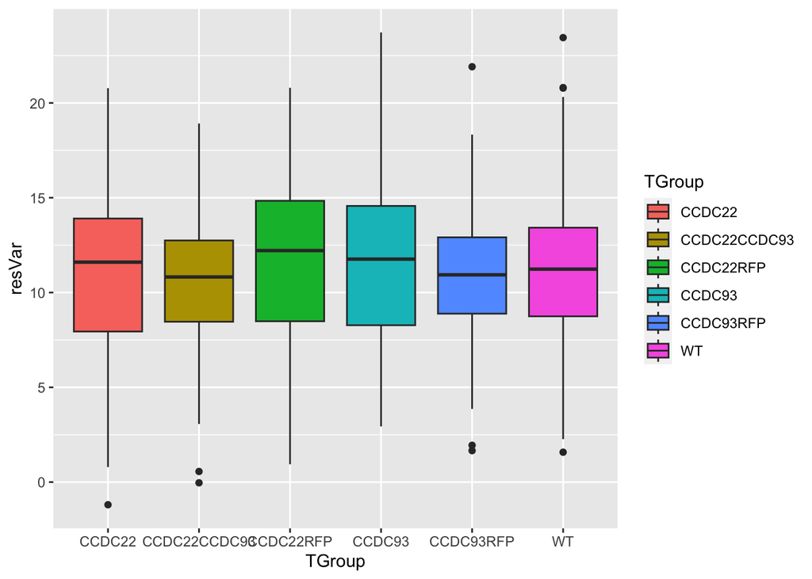

```r
# Pr(>F) p-value associated with the F-statistic
# If Pr(>F) is < 0.05, then at least one of the groups is different
# Results from multiple runs
# F value1
# 3.416318 | 4.355224 | 8.987862
#     Pr(>F)1
# 0.004859086 | 0.0007015046 | 3.780543e-08

# Use ggplot to visualize the ANOVA data
ANOPlot <- ggplot(data=ANOdata) +
  aes(x=TGroup,y=resVar,fill=TGroup) +
  geom_boxplot()
print(ANOPlot)
```

```r
################################
# Adjust sample size to n=100
################################

nGroup <- 6 # number of treatment groups
nName <- c("WT","CCDC22", "CCDC93", "CCDC22CCDC93", "CCDC22RFP", "CCDC93RFP") # names of groups
nSize <- c(100,100,100,100,100,100) # number of observations in each group, these are all equal in the simulated dataset
# the mean and variance are estimated using pilot trial numbers

nMean <- c(11.8,9.6,11.3,10.1,10.9,10.9) # mean of each group
nSD <- c(4.6,4.8,4.8,4.1,4.2,4.3) # standard deviation of each group

# id vector for each row, just numbers each row for organization and/or reference
ID <- 1:(sum(nSize))

# create a vector by concatenating six sets of random normal variables
# reVar is the response variable, root length
resVar <- c(rnorm(n=nSize[1],mean=nMean[1],sd=nSD[1]),
            rnorm(n=nSize[2],mean=nMean[2],sd=nSD[2]),
            rnorm(n=nSize[3],mean=nMean[3],sd=nSD[3]),
            rnorm(n=nSize[4],mean=nMean[4],sd=nSD[4]),
            rnorm(n=nSize[5],mean=nMean[5],sd=nSD[5]),
            rnorm(n=nSize[6],mean=nMean[6],sd=nSD[6]))
# sets up single column with all data, this is now in long form

TGroup <- rep(nName,nSize) # TGruop = genotype
ANOdata <- data.frame(ID,TGroup,resVar) # create dataframe
str(ANOdata)
```

```
## 'data.frame':    600 obs. of  3 variables:
##  $ ID    : int  1 2 3 4 5 6 7 8 9 10 ...
##  $ TGroup: chr  "WT" "WT" "WT" "WT" ...
##  $ resVar: num  14.4 14.3 10.4 12.6 15 ...
```

```r
# print(ANOdata)

# Run basic ANOVA
# the aggregate function calculates the mean of resVar (root length)for each level
# of TGroup (genotype) in the ANOdata data frame
ANOmodel <- aov(resVar~TGroup,data=ANOdata)
print(ANOmodel)
```

```
## Call:
##    aov(formula = resVar ~ TGroup, data = ANOdata)
##
## Terms:
##                    TGroup Residuals
## Sum of Squares    314.952 12279.681
## Deg. of Freedom         5       594
##
## Residual standard error: 4.546742
## Estimated effects may be unbalanced
```

```r
print(summary(ANOmodel)) # Estimated effects may be unbalanced, not sure if this message is a problem?
```

```
##              Df Sum Sq Mean Sq F value Pr(>F)
## TGroup        5    315   62.99   3.047   0.01 *
## Residuals   594  12280   20.67
## ---
## Signif. codes:  0 '***' 0.001 '**' 0.01 '*' 0.05 '.' 0.1 ' ' 1
```

```r
z <- summary(ANOmodel)
str(z)
```

```
## List of 1
##  $ :Classes 'anova' and 'data.frame':    2 obs. of  5 variables:
##   ..$ Df     : num [1:2] 5 594
##   ..$ Sum Sq : num [1:2] 315 12280
##   ..$ Mean Sq: num [1:2] 63 20.7
##   ..$ F value: num [1:2] 3.05 NA
##   ..$ Pr(>F) : num [1:2] 0.01 NA
##  - attr(*, "class")= chr [1:2] "summary.aov" "listof"
```

```r
aggregate(resVar~TGroup,data=ANOdata,FUN=mean)
```

```
##         TGroup    resVar
## 1       CCDC22  9.624771
## 2 CCDC22CCDC93 10.080998
## 3    CCDC22RFP 11.152914
## 4       CCDC93 10.887000
## 5    CCDC93RFP 10.712720
## 6           WT 11.871664
```

```r
unlist(z)
```

```
##          Df1          Df2      Sum Sq1      Sum Sq2     Mean Sq1     Mean Sq2
## 5.000000e+00 5.940000e+02 3.149521e+02 1.227968e+04 6.299043e+01 2.067286e+01
##     F value1     F value2      Pr(>F)1      Pr(>F)2
## 3.047010e+00           NA 1.002252e-02           NA
```

```r
unlist(z)[7] # F value1
```

```
## F value1
##  3.04701
```

```r
ANOsum <- list(Fval=unlist(z)[7],probF=unlist(z)[9])
ANOsum  # Pr(>F)1 multiple run results
```

```
## $Fval
## F value1
##  3.04701
##
## $probF
##    Pr(>F)1
## 0.01002252
```

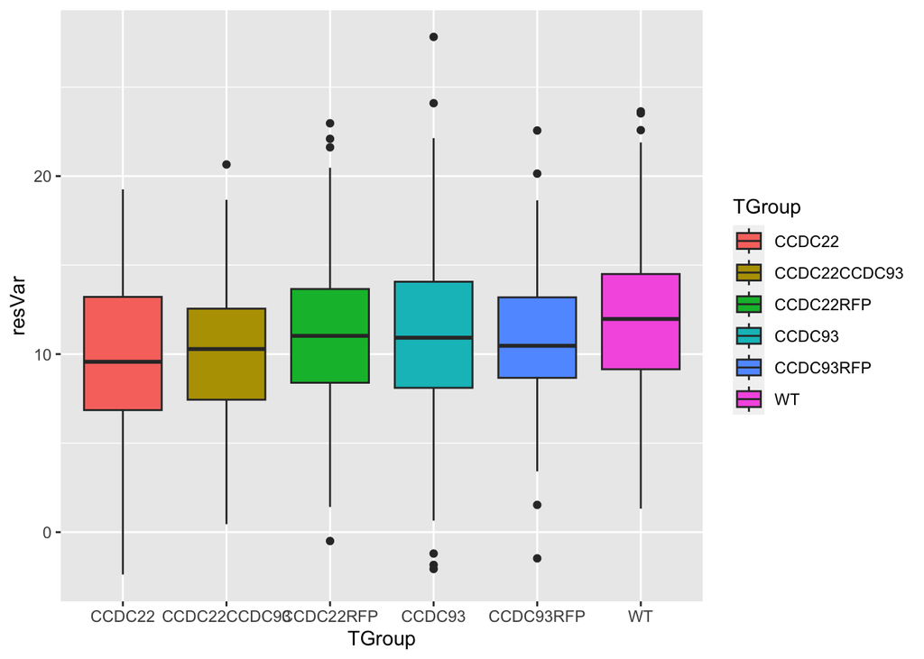

```r
# Pr(>F) p-value associated with the F-statistic
# If Pr(>F) is < 0.05, then at least one of the groups is different
# Multiple run results
#  F value1
# 3.913523  | 5.355109   | 4.928941
#  Pr(>F)1
# 0.001689342  | 7.961116e-05 | 0.0001980238

# Use ggplot to visualize the ANOVA data
ANOPlot <- ggplot(data=ANOdata) +
  aes(x=TGroup,y=resVar,fill=TGroup) +
  geom_boxplot()
print(ANOPlot)
```

If you have time, try repeating this exercise with one of the more sophisticated distributions, such as the gamma or negative binomial (depending on the kind of data you have). You will have to spend some time figuring out by trial and error the parameter values you will need to generate appropriate means and variances of the different groups.

*I’ll try at some point, but in the interest of time, I am submitting this now :)*